# 14-2-1 checks

Abhishek Singh

01/02/2023

## 14-2-1 update summary

Data for 1950 to 2022 have been created and saved as 2023-02-01_14-2-1.csv in the 14-2-1 Output folder.

### Check configurations

Please check that the information below is as you expect. In particular, pay attention to the time since data were saved, to check that previously downloaded data have not accidentally been used.

These settings can all be adjusted in `config.R`

Files used to create the new data were downloaded and saved in 14-2-1/Example_Input.

**Total extent and proportion of protected areas at sea (ONS)**

Protected areas data are in the file ukbi2022-ds-c1.xlsx.

This file was saved at 2023-01-24 19:10:39: It has been 7.85 days since the file was saved in Example_Input

The tab used is called Data_Extent.

### Check data

The charts below show the new data (just created) plotted on top of the old data, which has been downloaded from the live site. If there are unexpected discrepancies in the lines please investigate the reasons for these discrepancies.

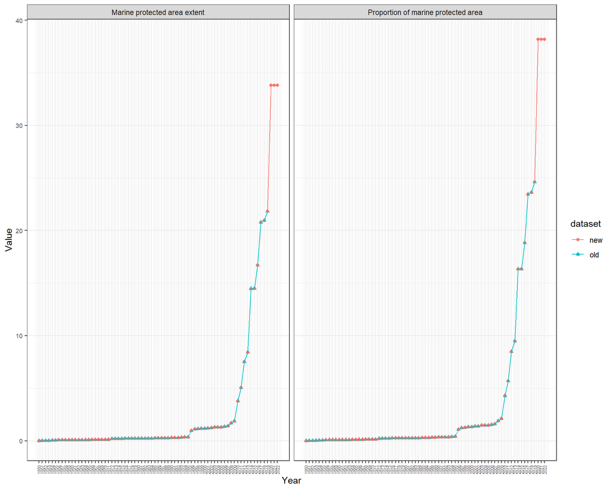

### Calculations

Calculations were made to generate the “Proportion of marine protected area” series. Proportion of marine protected area is calculated using the following formula. 100 * (Extent at sea - million hectares / UK sea area). See C1. Protected Areas for more information on methodology.

The calculations used to create these data were:

```
protected_area_main_data['Proportion_of_area_protected']  <-round((protected_area_main_data['At_Sea']/protected_area_main_data['UK_marine_area'])*100,2)
```

Warning: This is copied from `update_14-2-1.R` and will not dynamically update if that code is changed.